# Report for homework

Nurşen Töre

3/15/2021

# Loading and preprocessing the data

```r
fileurl="https://d396qusza40orc.cloudfront.net/repdata%2Fdata%2Factivity.zip"
download.file(fileurl,'./activity.zip', mode = 'wb')
unzip("activity.zip", exdir = getwd())
dat<-read_csv("activity.csv")
head(dat)
```

```
## # A tibble: 6 x 3
##   steps date       interval
##   <dbl> <date>        <dbl>
## 1    NA 2012-10-01        0
## 2    NA 2012-10-01        5
## 3    NA 2012-10-01       10
## 4    NA 2012-10-01       15
## 5    NA 2012-10-01       20
## 6    NA 2012-10-01       25
```

# What is mean total number of steps taken per day?

Calculate the total number of steps taken per day

```r
totwalk<-dat%>%
  group_by(date)%>%
  summarize(totwalk=sum(steps,na.rm=TRUE))
```

Make a histogram of the total number of steps taken each day

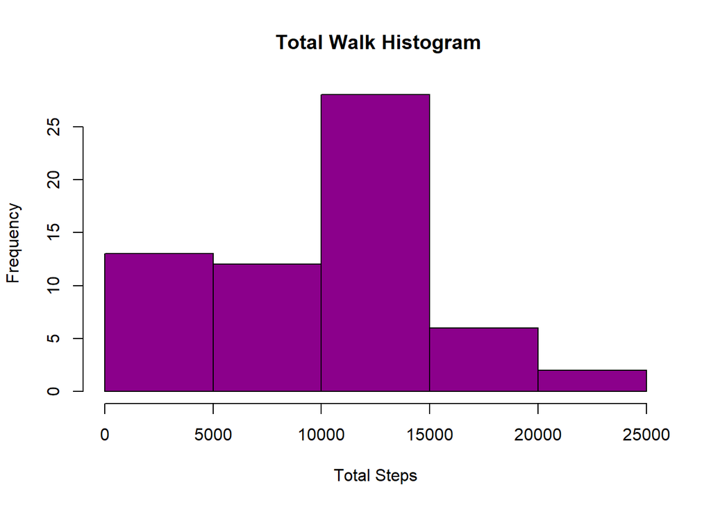

```r
with(totwalk,hist(totwalk,main=" Total Walk Histogram",
                  xlab="Total Steps",col="darkmagenta"))
```

Calculate and report the mean and median of the total number of steps taken per day

```r
summ<-summary(totwalk$totwalk)
summ["Median"]
```

```
## Median
##  10395
```

```r
summ["Mean"]
```

```
##    Mean
## 9354.23
```

# What is the average daily activity pattern?

Make a time series plot of the 5-minute interval (x-axis) and the average number of steps taken, averaged across all days (y-axis)

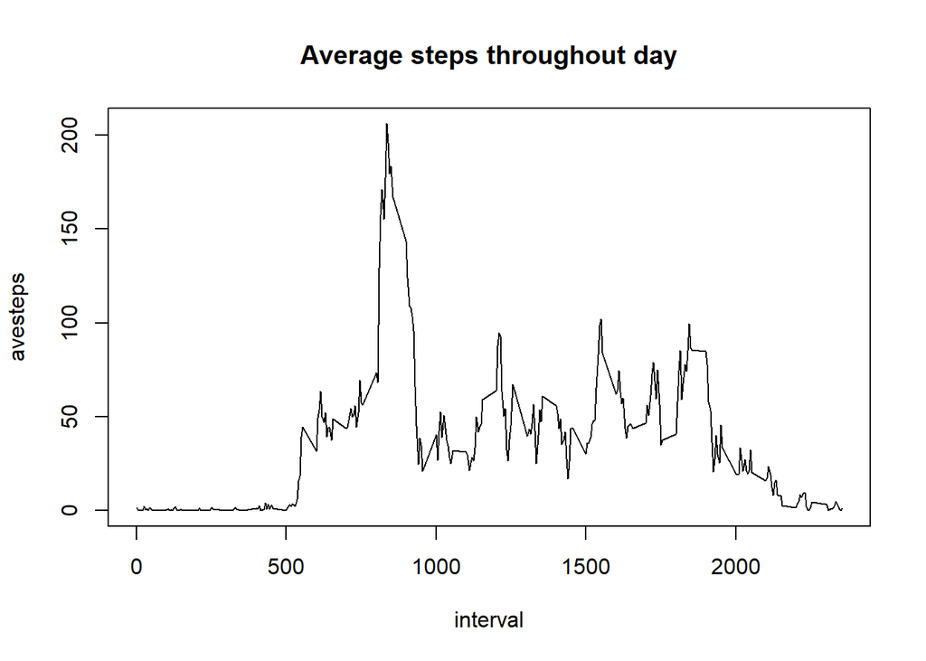

```r
avewalk<-dat%>%
  group_by(interval)%>%
  summarize(avesteps=mean(steps,na.rm=TRUE))
with(avewalk,plot(interval,avesteps,type = "l",main="Average steps throughout day"))
```

Which 5-minute interval, on average across all the days in the dataset, contains the maximum number of steps?

```r
avewalk%>%filter(avesteps==max(avesteps))%>%
  select(interval)
```

```
## # A tibble: 1 x 1
##   interval
##      <dbl>
## 1      835
```

# Imputing missing values

Calculate and report the total number of missing values in the dataset (i.e. the total number of rows with NAs)

```r
sum(is.na(dat))
```

```
## [1] 2304
```

Devise a strategy for filling in all of the missing values in the dataset. I will use the mean for that 5-minute interval.

Create a new dataset that is equal to the original dataset but with the missing data filled in.

```r
dat<-dat%>%group_by(interval)%>%
  mutate(steps = replace_na(steps, mean(steps,na.rm=TRUE)))%>%
  ungroup()
```

Make a histogram of the total number of steps taken each day and Calculate and report the mean and median total number of steps taken per day.

```r
totwalk<-dat%>%
  group_by(date)%>%
  summarize(totwalk=sum(steps,na.rm=TRUE))
summ<-summary(totwalk$totwalk)
summ["Median"]
```

```
##   Median
## 10766.19
```

```r
summ["Mean"]
```

```
##     Mean
## 10766.19
```

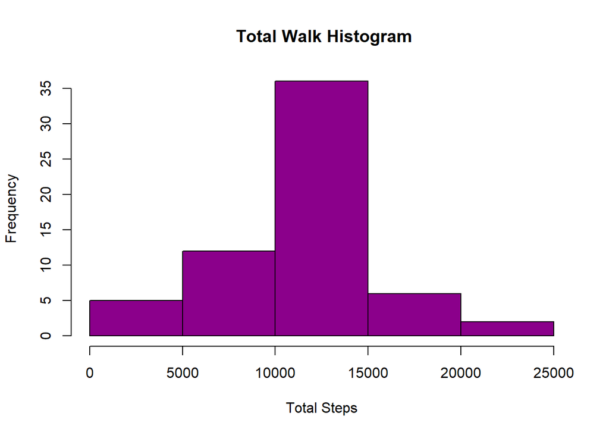

```r
with(totwalk,hist(totwalk,main=" Total Walk Histogram",xlab="Total Steps",col="darkmagenta"))
```

# Are there differences in activity patterns between weekdays and weekends?

Create a new factor variable in the dataset with two levels – “weekday” and “weekend” indicating whether a given date is a weekday or weekend day.

```r
weekavesteps<-dat%>%mutate(isweekday = case_when(
    weekdays(date)=="Monday"  ~ "Weekday",
    weekdays(date)=="Tuesday"  ~ "Weekday",
    weekdays(date)=="Wednesday"  ~ "Weekday",
    weekdays(date)=="Thursday"  ~ "Weekday",
    weekdays(date)=="Friday"  ~ "Weekday",
    weekdays(date)=="Saturday"  ~ "Weekend",
    weekdays(date)=="Sunday"  ~ "Weekend"),
    isweekday = factor(isweekday, levels=c("Weekday","Weekend")))%>%
  group_by(isweekday,interval)%>%
  summarize(avesteps=mean(steps,na.rm=TRUE))%>%ungroup()
```

Make a panel plot containing a time series plot (i.e. type = “l”) of the 5-minute interval (x-axis) and the average number of steps taken, averaged across all weekday days or weekend days (y-axis).

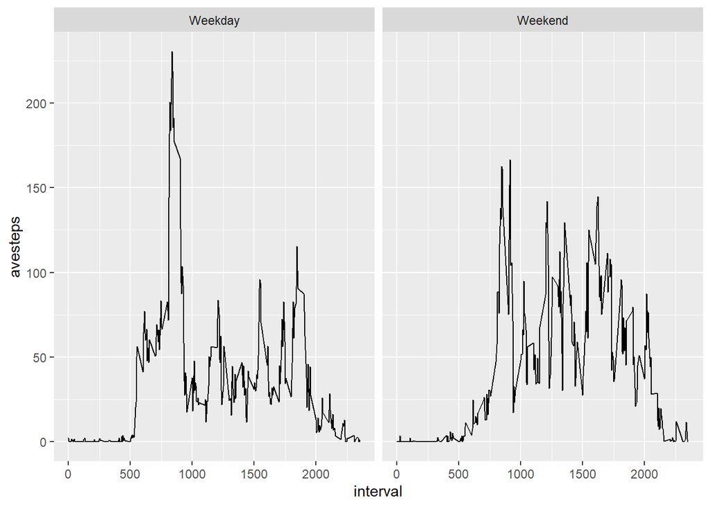

```r
p <- ggplot(weekavesteps, aes(interval, avesteps))
p+ geom_line()+facet_wrap(~ isweekday)
```